# Landslide Segmentation on EO Imagery

### U-Net vs FCN/DeepLab vs Transformer (Landslide4Sense)

## Objective

This notebook presents a structured comparison of semantic segmentation architectures for landslide detection using multispectral Earth Observation (EO) imagery.

We evaluate:

- U-Net (custom baseline)
- FCN-ResNet50
- DeepLabV3-ResNet50
- U-Net (TorchGeo)
- SegFormer-B0 (transformer-based)
- Swin Transformer (UPerNet)

Goal: understand the trade-offs between classical CNN-based segmentation, encoder–decoder architectures, and transformer-based models under multispectral input, small-data conditions and controlled setup.

## Workflow

1. Data loading
2. Image Preprocessing
3. Model training (6 architectures)
4. Evaluation and comparison (OA, F1, mean F1)
5. Visualization (predictions vs. ground truth masks)

## Dataset

We use **a subset of the Landslide4Sense dataset**:

- 14-channel input (spectral + topographic)
  - 12 multispectral bands from Sentinel-2 (B1–B12)
  - 1 slope band derived from ALOS PALSAR (B13)
  - 1 elevation band (DEM) from ALOS PALSAR (B14)
- Pixel-wise annotations (landslide vs. non-landslide)
- Image–mask pairs (~10 m resolution, 128 × 128 patches)

The dataset is split into training and test sets.  
(ref: https://github.com/iarai/Landslide4Sense-2022)

## Data Loading

```python
import time
import random
import numpy as np
import matplotlib.pyplot as plt

import torch
from torch import nn
import torch.nn.functional as F
from torch.utils.data import Dataset
import torchvision.transforms as T
import torchvision.models as models
import torchvision.models.segmentation as seg_models

from torchgeo.models import unet as unet_geo
from transformers import (SegformerForSemanticSegmentation, UperNetForSemanticSegmentation)

if torch.cuda.is_available():
    device = torch.device("cuda")
    print("Using GPU!")
else:
    device = torch.device("cpu")
    print("Using CPU!")
```

```
Using GPU!
```

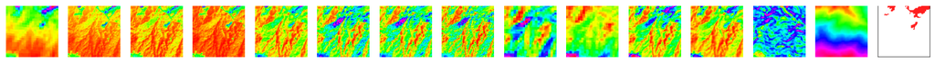

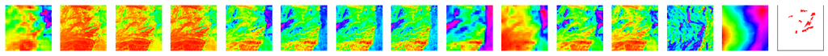

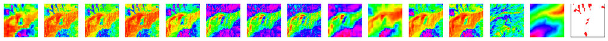

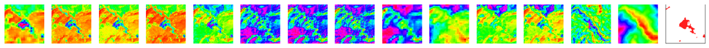

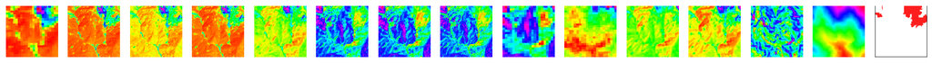

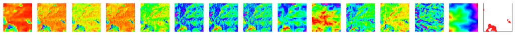

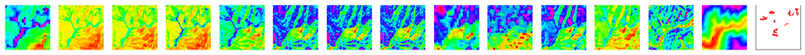

```python
# Visualization
import h5py

def index2bgr_z(c_map):

    # mapping W x H x 1 class index to W x H x 3 BGR image
    im_col, im_row = np.shape(c_map)
    c_map_r = np.ones((im_col, im_row), 'uint8')*255
    c_map_g = np.ones((im_col, im_row), 'uint8')*255
    c_map_b = np.ones((im_col, im_row), 'uint8')*255
    c_map_r[c_map == 1] = 255
    c_map_g[c_map == 1] = 30
    c_map_b[c_map == 1] = 30

    c_map_rgb = np.zeros((im_col, im_row, 3), 'uint8')
    c_map_rgb[:, :, 0] = c_map_r
    c_map_rgb[:, :, 1] = c_map_g
    c_map_rgb[:, :, 2] = c_map_b

    return c_map_rgb

train_im_path = './TrainData/img/'
train_mask_path = './TrainData/mask/'

for index in range(20,50):
    with h5py.File(train_im_path+'image_'+str(index)+'.h5', 'r') as hf:
        im = hf['img'][:]
    with h5py.File(train_mask_path+'mask_'+str(index)+'.h5', 'r') as hf:
        mask = hf['mask'][:]
    if np.sum(mask)>500:
        plt.figure(figsize=(20,5))
        for i in range(14):
            plt.subplot(1,15,i+1)
            plt.imshow(im[:,:,i], cmap="hsv")
            plt.axis('off')
        plt.subplot(1,15,15)
        label_rgb = index2bgr_z(mask)
        label_rgb[0,:,:]=0
        label_rgb[-1,:,:]=0
        label_rgb[:,0,:]=0
        label_rgb[:,-1,:]=0
        plt.imshow(label_rgb)
        plt.axis('off')
```

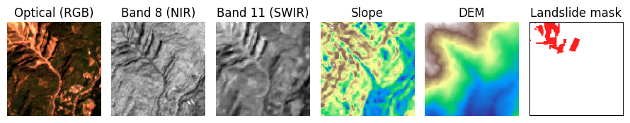

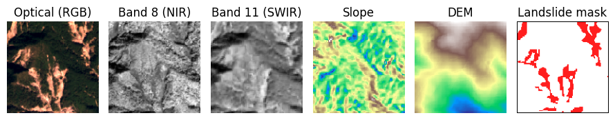

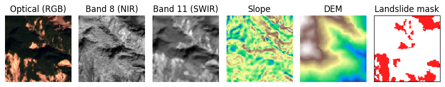

```python
for index in [2, 1576, 1739]:
    with h5py.File(train_im_path + 'image_' + str(index) + '.h5', 'r') as hf:
        im = hf['img'][:]
    with h5py.File(train_mask_path + 'mask_' + str(index) + '.h5', 'r') as hf:
        mask = hf['mask'][:]

    if np.sum(mask) > 500:
        plt.figure(figsize=(9, 2))

        # --- RGB composite (Sentinel-2: B4, B3, B2) ---
        rgb = np.stack([im[:, :, 3], im[:, :, 2], im[:, :, 1]], axis=-1)
        rgb = (rgb - np.percentile(rgb, 2)) / (np.percentile(rgb, 98) - np.percentile(rgb, 2) + 1e-6)
        rgb = np.clip(rgb, 0, 1)

        plt.subplot(1, 6, 1)
        plt.imshow(rgb)
        plt.title("Optical (RGB)")
        plt.axis('off')

        # --- Band 8 (NIR) ---
        plt.subplot(1, 6, 2)
        plt.imshow(im[:, :, 7], cmap="gray")
        plt.title("Band 8 (NIR)")
        plt.axis('off')

        # --- Band 11 (SWIR) ---
        plt.subplot(1, 6, 3)
        plt.imshow(im[:, :, 10], cmap="gray")
        plt.title("Band 11 (SWIR)")
        plt.axis('off')

        # --- Slope ---
        plt.subplot(1, 6, 4)
        plt.imshow(im[:, :, 12], cmap="terrain")
        plt.title("Slope")
        plt.axis('off')

        # --- DEM ---
        plt.subplot(1, 6, 5)
        plt.imshow(im[:, :, 13], cmap="terrain")
        plt.title("DEM")
        plt.axis('off')

        # --- Landslide mask (red) ---
        plt.subplot(1, 6, 6)
        label_rgb = index2bgr_z(mask)
        label_rgb[0, :, :] = 0
        label_rgb[-1, :, :] = 0
        label_rgb[:, 0, :] = 0
        label_rgb[:, -1, :] = 0
        plt.imshow(label_rgb)
        plt.title("Landslide mask")
        plt.axis('off')

        plt.tight_layout()
        plt.show()
```

Multimodal inputs include RGB (visual context), NIR (Band 8) for vegetation contrast, SWIR (Band 11) for moisture/material differences, and terrain features (slope, DEM), providing complementary cues for landslide detection.

## Image Preprocessing

```python
# Data loader
from tqdm import tqdm

class LandslideDataSet(Dataset):
    def __init__(self, data_dir, list_path, max_iters=None,set='labeled'):
        self.list_path = list_path
        self.mean = [-0.4914, -0.3074, -0.1277, -0.0625, 0.0439, 0.0803, 0.0644, 0.0802, 0.3000, 0.4082, 0.0823, 0.0516, 0.3338, 0.7819]
        self.std = [0.9325, 0.8775, 0.8860, 0.8869, 0.8857, 0.8418, 0.8354, 0.8491, 0.9061, 1.6072, 0.8848, 0.9232, 0.9018, 1.2913]
        self.set = set
        self.img_ids = [i_id.strip() for i_id in open(list_path)]

        if not max_iters==None:
            n_repeat = int(np.ceil(max_iters / len(self.img_ids)))
            self.img_ids = self.img_ids * n_repeat + self.img_ids[:max_iters-n_repeat*len(self.img_ids)]

        self.files = []

        if set=='labeled':
            for name in self.img_ids:
                img_file = data_dir + name
                label_file = data_dir + name.replace('img','mask').replace('image','mask')
                self.files.append({
                    'img': img_file,
                    'label': label_file,
                    'name': name
                })
        elif set=='unlabeled':
            for name in self.img_ids:
                img_file = data_dir + name
                self.files.append({
                    'img': img_file,
                    'name': name
                })

    def __len__(self):
        return len(self.files)


    def __getitem__(self, index):
        datafiles = self.files[index]

        if self.set=='labeled':
            with h5py.File(datafiles['img'], 'r') as hf:
                image = hf['img'][:]
            with h5py.File(datafiles['label'], 'r') as hf:
                label = hf['mask'][:]
            name = datafiles['name']

            image = np.asarray(image, np.float32)
            label = np.asarray(label, np.float32)

            image = image.transpose((-1, 0, 1))
            size = image.shape

            for i in range(len(self.mean)):
                image[i,:,:] -= self.mean[i]
                image[i,:,:] /= self.std[i]

            return image.copy(), label.copy(), np.array(size), name

        else:
            with h5py.File(datafiles['img'], 'r') as hf:
                image = hf['img'][:]
            name = datafiles['name']

            image = np.asarray(image, np.float32)
            image = image.transpose((-1, 0, 1))
            size = image.shape

            for i in range(len(self.mean)):
                image[i,:,:] -= self.mean[i]
                image[i,:,:] /= self.std[i]

            return image.copy(), np.array(size), name
```

```python
# Training setup
name_classes = ['Non-Landslide','Landslide']
epsilon = 1e-14

input_size = (128, 128)
batch_size = 32
num_steps_stop = 100
learning_rate = 2.5e-4
```

```python
# Training/test split
f_train = open('./TrainData/train.txt', 'w')
f_test = open('./TrainData/test.txt', 'w')

for i in range(959): #25% for training
    f_train.writelines('TrainData/img/image_'+str(i+1)+'.h5\n')

for i in range(959,3799):
    f_test.writelines('TrainData/img/image_'+str(i+1)+'.h5\n')

f_train.close()
f_test.close()

src_loader = torch.utils.data.DataLoader(
                LandslideDataSet('./', 'TrainData/train.txt', max_iters=num_steps_stop*batch_size,set='labeled'),
                batch_size=batch_size, shuffle=True)

test_loader = torch.utils.data.DataLoader(
                LandslideDataSet('./', 'TrainData/test.txt',set='labeled'),
                batch_size=1, shuffle=False)
```

```python
def count_lines(file_path):
    with open(file_path, 'r') as f:
        return len(f.readlines())

print("Dataset sizes:")
print("Train:", count_lines('./TrainData/train.txt'))
print("Test:", count_lines('./TrainData/test.txt'))
```

```
Dataset sizes:
Train: 959
Test: 2840
```

## Model training (6 architectures)

U-Net (custom baseline), FCN-ResNet50, DeepLabV3-ResNet50, U-Net (TorchGeo), SegFormer-B0 (transformer-based), and Swin Transformer (UPerNet) are trained under a unified pipeline.

```python
# U-Net
class DoubleConv(nn.Module):
    def __init__(self, in_channels, out_channels, mid_channels=None):
        super().__init__()
        if not mid_channels:
            mid_channels = out_channels
        self.double_conv = nn.Sequential(
            nn.Conv2d(in_channels, mid_channels, kernel_size=3, padding=1),
            nn.BatchNorm2d(mid_channels),
            nn.ReLU(inplace=True),
            nn.Conv2d(mid_channels, out_channels, kernel_size=3, padding=1),
            nn.BatchNorm2d(out_channels),
            nn.ReLU(inplace=True)
        )

    def forward(self, x):
        return self.double_conv(x)

class Down(nn.Module):
    def __init__(self, in_channels, out_channels):
        super().__init__()
        self.maxpool_conv = nn.Sequential(
            nn.MaxPool2d(2),
            DoubleConv(in_channels, out_channels)
        )

    def forward(self, x):
        return self.maxpool_conv(x)

class Up(nn.Module):
    def __init__(self, in_channels, out_channels, bilinear=True):
        super().__init__()

        if bilinear:
            self.up = nn.Upsample(scale_factor=2, mode='bilinear', align_corners=True)
            self.conv = DoubleConv(in_channels, out_channels, in_channels // 2)
        else:
            self.up = nn.ConvTranspose2d(in_channels, in_channels // 2, kernel_size=2, stride=2)
            self.conv = DoubleConv(in_channels, out_channels)

    def forward(self, x1, x2):
        x1 = self.up(x1)
        diffY = x2.size()[2] - x1.size()[2]
        diffX = x2.size()[3] - x1.size()[3]

        x1 = F.pad(x1, [diffX // 2, diffX - diffX // 2,
                        diffY // 2, diffY - diffY // 2])
        x = torch.cat([x2, x1], dim=1)
        return self.conv(x)

class OutConv(nn.Module):
    def __init__(self, in_channels, out_channels):
        super(OutConv, self).__init__()
        self.conv = nn.Conv2d(in_channels, out_channels, kernel_size=1)

    def forward(self, x):
        return self.conv(x)

class unet(nn.Module):
    def __init__(self, n_classes, n_channels=14, bilinear=True):
        super(unet, self).__init__()
        self.n_channels = n_channels
        self.n_classes = n_classes
        self.bilinear = bilinear

        self.inc = DoubleConv(n_channels, 64)
        self.down1 = Down(64, 128)
        self.down2 = Down(128, 256)
        self.down3 = Down(256, 512)
        factor = 2 if bilinear else 1
        self.down4 = Down(512, 1024 // factor)
        self.up1 = Up(1024, 512 // factor, bilinear)
        self.up2 = Up(512, 256 // factor, bilinear)
        self.up3 = Up(256, 128 // factor, bilinear)
        self.up4 = Up(128, 64, bilinear)
        self.outc = OutConv(64, n_classes)

    def forward(self, x):
        x1 = self.inc(x)
        x2 = self.down1(x1)
        x3 = self.down2(x2)
        x4 = self.down3(x3)
        x5 = self.down4(x4)
        x = self.up1(x5, x4)
        x = self.up2(x, x3)
        x = self.up3(x, x2)
        x = self.up4(x, x1)
        logits = self.outc(x)
        return logits

def eval_image(predict,label,num_classes):
    index = np.where((label>=0) & (label<num_classes))
    predict = predict[index]
    label = label[index]

    TP = np.zeros((num_classes, 1))
    FP = np.zeros((num_classes, 1))
    TN = np.zeros((num_classes, 1))
    FN = np.zeros((num_classes, 1))

    for i in range(0,num_classes):
        TP[i] = np.sum(label[np.where(predict==i)]==i)
        FP[i] = np.sum(label[np.where(predict==i)]!=i)
        TN[i] = np.sum(label[np.where(predict!=i)]!=i)
        FN[i] = np.sum(label[np.where(predict!=i)]==i)

    return TP,FP,TN,FN,len(label)
```

```python
# Model Initialization

# CNN-based models:
# 1."unet"
# 2."fcn", "fcn_rgb"
# 3."deeplabv3", "deeplabv3_rgb"
# 4."unet_geo"

# Transformer-based models:
# 5."segformer", "segformer_rgb"
# 6."swin", "swin_rgb"

model_name = "unet"

num_classes = 2

if model_name == "unet":
    model = unet(n_classes=num_classes)

elif model_name in ["fcn", "fcn_rgb"]:
    weights = "COCO_WITH_VOC_LABELS_V1" if model_name == "fcn_rgb" else None
    model = seg_models.fcn_resnet50(weights=weights)
    if model_name == "fcn":
        model.band_reduction = nn.Conv2d(14, 3, kernel_size=1)
    model.classifier[4] = nn.Conv2d(512, num_classes, kernel_size=1)

elif model_name in ["deeplabv3", "deeplabv3_rgb"]:
    weights = "COCO_WITH_VOC_LABELS_V1" if model_name == "deeplabv3_rgb" else None
    model = seg_models.deeplabv3_resnet50(weights=weights)
    if model_name == "deeplabv3":
        model.band_reduction = nn.Conv2d(14, 3, kernel_size=1)
    model.classifier[4] = nn.Conv2d(256, num_classes, kernel_size=1)

elif model_name == "unet_geo":
    model = unet_geo(in_channels=14, classes=num_classes)

elif model_name in ["segformer", "segformer_rgb"]:
    model = SegformerForSemanticSegmentation.from_pretrained(
        "nvidia/segformer-b0-finetuned-ade-512-512",
        num_labels=num_classes,
        ignore_mismatched_sizes=True
    )
    if model_name == "segformer":
        model.band_reduction = nn.Conv2d(14, 3, kernel_size=1)

elif model_name in ["swin", "swin_rgb"]:
    model = UperNetForSemanticSegmentation.from_pretrained(
        "openmmlab/upernet-swin-tiny",
        num_labels=num_classes,
        ignore_mismatched_sizes=True
    )
    if model_name == "swin":
        model.band_reduction = nn.Conv2d(14, 3, kernel_size=1)

model = model.to(device)

optimizer = torch.optim.Adam(model.parameters(), lr=learning_rate, weight_decay=5e-4)
weights = torch.tensor([1.0, 3.0]).to(device)
cross_entropy_loss = nn.CrossEntropyLoss(weight=weights, ignore_index=255)
```

```python
interp = nn.Upsample(size=(input_size[1], input_size[0]), mode="bilinear")
hist = np.zeros((num_steps_stop, 3))
F1_best = 0.0

# handle different output formats across architectures
def forward_pass(model, images, model_name, interp):

    if model_name in ["fcn_rgb", "deeplabv3_rgb", "segformer_rgb", "swin_rgb"]:
        # B4 (R), B3 (G), B2 (B)
        images = images[:, [3, 2, 1], :, :]

    if model_name in ["fcn", "deeplabv3", "segformer", "swin"]:
        images = model.band_reduction(images)

    if model_name in ["segformer", "segformer_rgb", "swin", "swin_rgb"]:
        pred = model(images).logits
    else:
        pred = model(images)

    if isinstance(pred, dict):  # FCN / DeepLab
        pred = pred["out"]

    pred = interp(pred)
    return pred

def train_step(model, images, labels, optimizer, criterion, model_name, interp):
    model.train()
    optimizer.zero_grad()

    pred = forward_pass(model, images, model_name, interp)
    loss = criterion(pred, labels)

    _, pred_label = torch.max(pred, 1)
    pred_np = pred_label.detach().cpu().numpy()
    labels_np = labels.cpu().numpy()

    batch_oa = np.sum(pred_np == labels_np) / labels_np.size

    loss.backward()
    optimizer.step()

    return loss.item(), batch_oa

def evaluate_model(model, test_loader, model_name, interp, epsilon, name_classes, device):
    print("Testing..........")
    model.eval()

    TP_all = np.zeros((2, 1))
    FP_all = np.zeros((2, 1))
    TN_all = np.zeros((2, 1))
    FN_all = np.zeros((2, 1))
    n_valid_sample_all = 0
    F1 = np.zeros((2, 1))

    for _, batch in enumerate(test_loader):
        image, label, _, name = batch
        label = label.squeeze().numpy()
        image = image.float().to(device)

        with torch.no_grad():
            pred = forward_pass(model, image, model_name, interp)

        _, pred = torch.max(nn.functional.softmax(pred, dim=1).detach(), 1)
        pred = pred.squeeze().data.cpu().numpy()

        TP, FP, TN, FN, n_valid_sample = eval_image(pred.reshape(-1), label.reshape(-1), 2)
        TP_all += TP
        FP_all += FP
        TN_all += TN
        FN_all += FN
        n_valid_sample_all += n_valid_sample

    OA = np.sum(TP_all) * 1.0 / n_valid_sample_all
    for i in range(2):
        P = TP_all[i] * 1.0 / (TP_all[i] + FP_all[i] + epsilon)
        R = TP_all[i] * 1.0 / (TP_all[i] + FN_all[i] + epsilon)
        F1[i] = 2.0 * P * R / (P + R + epsilon)
        if i == 1:
            print("===>" + name_classes[i] + " Precision: %.2f" % (P.item() * 100))
            print("===>" + name_classes[i] + " Recall: %.2f" % (R.item() * 100))
            print("===>" + name_classes[i] + " F1: %.2f" % (F1[i].item() * 100))

    mF1 = np.mean(F1)
    print("===> mean F1: %.2f OA: %.2f" % (mF1 * 100, OA * 100))

    return F1, OA, mF1

# saving the best checkpoint
def update_best(model, F1, F1_best, model_name):
    if F1[1].item() > F1_best:
        F1_best = F1[1].item()

        # Optional: save best model checkpoint
        # Disabled by default to avoid unintended overwrites during repeated experiments

        # print("Save Model")
        # checkpoint_name = f"best_{model_name}_landslide_F1.pth"
        # torch.save(model.state_dict(), checkpoint_name)

    return F1_best
```

```python
# training loop with periodic evaluation
for batch_id, src_data in enumerate(src_loader):
    if batch_id == num_steps_stop:
        break
    start_time = time.time()
    images, labels, _, _ = src_data
    images = images.to(device)
    labels = labels.to(device).long()

    loss_value, batch_oa = train_step(model, images, labels, optimizer, cross_entropy_loss, model_name, interp)

    hist[batch_id, 0] = loss_value
    hist[batch_id, 1] = batch_oa
    hist[batch_id, 2] = time.time() - start_time

    if (batch_id + 1) % 10 == 0:
        print(
            "Iter %d/%d Time cost per iter: %.2f Batch_OA = %.1f cross_entropy_loss = %.3f"
            % (
                batch_id + 1,
                num_steps_stop,
                10 * np.mean(hist[batch_id - 9:batch_id + 1, 2]),
                np.mean(hist[batch_id - 9:batch_id + 1, 1]) * 100,
                np.mean(hist[batch_id - 9:batch_id + 1, 0])
            )
        )

    if (batch_id + 1) % 100 == 0:
        F1, OA, mF1 = evaluate_model(model, test_loader, model_name, interp, epsilon, name_classes, device)
        F1_best = update_best(model, F1, F1_best, model_name)
```

```
Iter 10/100 Time cost per iter: 3.81 Batch_OA = 80.8 cross_entropy_loss = 0.584
Iter 20/100 Time cost per iter: 3.33 Batch_OA = 97.3 cross_entropy_loss = 0.363
Iter 30/100 Time cost per iter: 3.19 Batch_OA = 97.4 cross_entropy_loss = 0.297
Iter 40/100 Time cost per iter: 3.19 Batch_OA = 97.6 cross_entropy_loss = 0.263
Iter 50/100 Time cost per iter: 3.46 Batch_OA = 98.0 cross_entropy_loss = 0.236
Iter 60/100 Time cost per iter: 3.77 Batch_OA = 97.6 cross_entropy_loss = 0.237
Iter 70/100 Time cost per iter: 4.26 Batch_OA = 98.1 cross_entropy_loss = 0.210
Iter 80/100 Time cost per iter: 3.55 Batch_OA = 97.8 cross_entropy_loss = 0.202
Iter 90/100 Time cost per iter: 3.82 Batch_OA = 97.9 cross_entropy_loss = 0.187
Iter 100/100 Time cost per iter: 3.75 Batch_OA = 97.6 cross_entropy_loss = 0.179
Testing..........
===>Landslide Precision: 59.72
===>Landslide Recall: 59.89
===>Landslide F1: 59.81
===> mean F1: 79.46 OA: 98.27
```

## Evaluation

Final test-set evaluation

```python
checkpoint_path = "best_unet_landslide_F1.pth"

model.load_state_dict(torch.load(checkpoint_path, map_location=device))
model = model.to(device)
model.eval()

F1, OA, mF1 = evaluate_model(model, test_loader, model_name, interp, epsilon, name_classes, device)
```

```
Testing..........
===>Landslide Precision: 62.46
===>Landslide Recall: 63.57
===>Landslide F1: 63.01
===> mean F1: 81.09 OA: 98.39
```

## Experimental Notes

Several variations were explored to identify factors that meaningfully impact landslide segmentation performance beyond the baseline.

- Training dynamics showed clear early convergence (100 - 300 epochs); extending to 300 epochs yielded no improvement and slight degradation, indicating limited benefit from prolonged optimization.
- Optimization settings were fixed across experiments to ensure a fair comparison, focusing the analysis on architectural, spectral, and loss-design effects rather than hyperparameter tuning; no evidence suggests that optimization is the primary bottleneck, although some variability across runs indicates sensitivity to training dynamics.
- Class-weighted CrossEntropy improved landslide detection under strong imbalance; moderate weighting (w = 3) balanced precision–recall, while low weighting led to under-detection (↑FN, ↓recall), and excessive weighting (w ≥ 10) caused overprediction (↑FP, ↓precision), reducing overall F1.
- Very long training provided only marginal gains, suggesting performance is not iteration-limited but driven by proper loss design. For fair comparison, all models were evaluated at 300 epochs, as more complex architectures typically require longer training to stabilize.
- Data augmentation (flip, rotation, scale/crop) consistently degraded performance, with rotations and flips causing the largest drops, indicating lack of rotation invariance and sensitivity to spatial transformations.
- The negative effect of geometric augmentation suggests direction-dependent physical information in the data, making spatial transformations harmful.
- Model comparison revealed a clear hierarchy (U-Net > SegFormer > Swin > DeepLabV3 ≈ FCN), indicating better generalization of simpler architectures under limited data.
- Learned spectral projection (14 → 3) improved CNN performance over direct multispectral input, demonstrating that compact spectral compression can be beneficial.
- RGB-pretrained weights degraded performance under projected multispectral input, suggesting a mismatch between pretrained filters and transformed spectral distributions.
- In contrast, pretrained weights improved performance under RGB-only input, confirming that transfer learning is effective when the input distribution aligns with RGB-based pretraining (e.g., ImageNet).

## Visualization

```python
saved_samples = []
for index in [68, 815, 2567]:

    images, labels, _, _ = test_loader.dataset[index]

    images = torch.from_numpy(images).unsqueeze(0).to(device)
    labels = torch.from_numpy(labels).unsqueeze(0).to(device)

    outputs = forward_pass(model, images, model_name, interp)
    preds = torch.argmax(outputs, dim=1)

    images = images.cpu().numpy()
    labels = labels.cpu().numpy()
    preds = preds.cpu().numpy()

    saved_samples.append((images[0], labels[0], preds[0]))
```

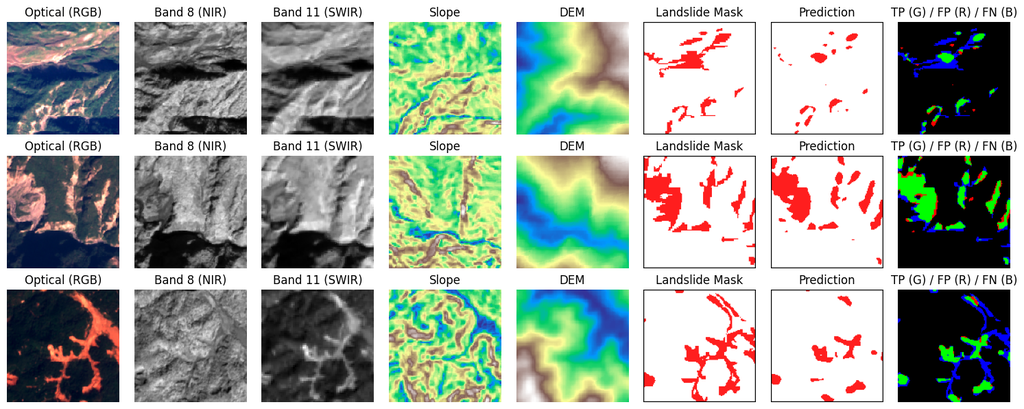

```python
n = len(saved_samples)
fig, axes = plt.subplots(n, 8, figsize=(15, 2.0 * n))

if n == 1:
    axes = axes[np.newaxis, :]

for i, (img, gt, pred) in enumerate(saved_samples):

    # --- Optical RGB composite (Sentinel-2: B4, B3, B2) ---
    rgb = np.stack([img[3], img[2], img[1]], axis=-1)
    rgb = (rgb - np.percentile(rgb, 2)) / (np.percentile(rgb, 98) - np.percentile(rgb, 2) + 1e-6)
    rgb = np.clip(rgb, 0, 1)

    axes[i, 0].imshow(rgb)
    axes[i, 0].set_title("Optical (RGB)")
    axes[i, 0].axis("off")

    # --- Band 8 (NIR) ---
    axes[i, 1].imshow(img[7], cmap="gray")
    axes[i, 1].set_title("Band 8 (NIR)")
    axes[i, 1].axis("off")

    # --- Band 11 (SWIR) ---
    axes[i, 2].imshow(img[10], cmap="gray")
    axes[i, 2].set_title("Band 11 (SWIR)")
    axes[i, 2].axis("off")

    # --- Slope ---
    axes[i, 3].imshow(img[12], cmap="terrain")
    axes[i, 3].set_title("Slope")
    axes[i, 3].axis("off")

    # --- DEM ---
    axes[i, 4].imshow(img[13], cmap="terrain")
    axes[i, 4].set_title("DEM")
    axes[i, 4].axis("off")

    # --- Landslide mask (Ground Truth) ---
    gt_rgb = index2bgr_z(gt).copy()
    gt_rgb[[0, -1], :, :] = 0
    gt_rgb[:, [0, -1], :] = 0

    axes[i, 5].imshow(gt_rgb)
    axes[i, 5].set_title("Landslide Mask")
    axes[i, 5].axis("off")

    # --- Prediction ---
    pred_rgb = index2bgr_z(pred).copy()
    pred_rgb[[0, -1], :, :] = 0
    pred_rgb[:, [0, -1], :] = 0

    axes[i, 6].imshow(pred_rgb)
    axes[i, 6].set_title("Prediction")
    axes[i, 6].axis("off")

    # --- Error Overlay (TP / FP / FN) ---
    tp = (pred == 1) & (gt == 1)
    fp = (pred == 1) & (gt == 0)
    fn = (pred == 0) & (gt == 1)

    overlay = np.zeros((*pred.shape, 3), dtype=np.uint8)
    overlay[tp] = [0, 255, 0]   # Green = True Positive
    overlay[fp] = [255, 0, 0]   # Red   = False Positive
    overlay[fn] = [0, 0, 255]   # Blue  = False Negative

    axes[i, 7].imshow(overlay)
    axes[i, 7].set_title("TP (G) / FP (R) / FN (B)")
    axes[i, 7].axis("off")

fig.tight_layout(h_pad=1.5)
plt.show()
```

## Model Comparison (300 Epochs – Controlled Setting)

| Model | Input Strategy | Landslide F1 (%) | Mean F1 (%) | OA (%) | Note |
| --- | --- | --- | --- | --- | --- |
| U-Net | 14 bands (direct) | 61.74 | 80.46 | 98.39 | Reference model |
| FCN (ResNet50) | 14 bands (direct) | 50.45 | 74.62 | 97.64 | Direct multispectral input |
| FCN (ResNet50) | 14 → 3 projection | 52.88 | 75.89 | 97.85 | Learned spectral compression |
| FCN (ResNet50) | RGB (B4,B3,B2) | 46.33 | 72.40 | 97.02 | Test RGB-only input |
| DeepLabV3 (ResNet50) | 14 → 3 projection | 52.99 | 75.95 | 97.87 | Learned spectral compression |
| DeepLabV3 (ResNet50) | RGB (B4,B3,B2) | 51.73 | 75.23 | 97.53 | Test RGB-only input |
| U-Net (TorchGeo) | 14 bands (direct) | 58.02 | 78.58 | 98.29 | Natural multispectral model |
| SegFormer | 14 → 3 projection | 59.56 | 79.26 | 97.97 | Transformer-based baseline |
| SegFormer | RGB (B4,B3,B2) | 47.67 | 72.89 | 96.34 | Test RGB-only input |
| Swin Transformer | 14 → 3 projection | 55.86 | 77.53 | 98.43 | Hierarchical transformer |
| Swin Transformer | RGB (B4,B3,B2) | 50.72 | 74.70 | 97.41 | Test RGB-only input |

## Peak Performance (100 Epochs – Early Convergence)

| Model | Input Strategy | Landslide F1 (%) | Mean F1 (%) | OA (%) | Note |
| --- | --- | --- | --- | --- | --- |
| U-Net | 14 bands (direct) | 63.01 | 81.09 | 98.39 | Best observed performance |

Key observations:

- Landslide F1 is the primary evaluation metric due to strong class imbalance; OA and Mean F1 may obscure minority-class performance differences
- U-Net provides the most consistent high performance under small-data conditions, with the best peak result observed
- Learned spectral projection (14→3) improves CNN performance over direct multispectral input
- Transformer-based models (SegFormer, Swin) remain competitive but do not show clear advantage in this small-data regime
- RGB-only input consistently underperforms, confirming the importance of multispectral information
- Performance differences are driven more by input representation than architectural complexity

## Conclusion

- Simple CNN-based architectures show more consistent performance than more complex models under limited data
- Results show moderate variance across runs, consistent with small-data training dynamics.
- Data characteristics (class imbalance and direction-dependent spatial structure) dominate performance; careful loss design is required, while geometric augmentation can degrade results
- Proper handling of multispectral input is critical for performance
- Increasing model complexity does not guarantee improvement without sufficient data scale
- Performance is driven more by input representation and controlled evaluation than architectural novelty

This study highlights that, under small-data multispectral EO conditions, model performance is primarily determined by input representation and training setup, with simpler CNN-based approaches providing the most reliable results.